# Household Demography model: sensitivity analysis on density-dependent (v.1.2)

## Preparation

```r
library(tidyr)
library(dplyr)
library(readr)
library(ggplot2)
library(gridExtra)
library(scales)
library(randomForest)
```

```r
plotDirectory <- "plots/v12_"
plot_file_format <- c("png", "eps")[1] # modify index number to change format
```

## Experiment design with stochastic parameter settings

### Generate parameter values with Sobol Sampling

```r
sobol_parameter_sample_dataFileName <- "data/v12_sobol_parameter_values.RData"

sobol_parameter_ranges <- list(
  `initial-num-households` = c(2, 50),
  `household_initial_age_distribution_min` = c(0, 5),
  `household_initial_age_distribution_max` = c(6, 60),
  `max_couple_count_distribution_min` = c(1, 2),
  `max_couple_count_distribution_max` = c(3, 8),
  `acceptable-kinship-degree-for-couples` = c(0, 9),
  `cdmlt-level` = c(1, 25),
  `c1-fert` = c(0, 0.5),
  `mu-fert` = c(15, 30),
  `sigma1-fert` = c(1, 10),
  `sigma2-fert` = c(5, 20),
  `c1-women` = c(0, 1),
  `mu-women` = c(15, 40),
  `sigma1-women` = c(1, 20),
  `sigma2-women` = c(1, 20),
  `c1-men` = c(0, 1),
  `mu-men` = c(15, 40),
  `sigma1-men` = c(1, 20),
  `sigma2-men` = c(1, 20),
  `carrying-capacity` = c(100, 10000),
  `density-effect-scaling-factor` = c(0.01, 0.5)
)
```

```r
library(randtoolbox)
set.seed(123)
n <- 2000  # Number of samples
k <- length(sobol_parameter_ranges)  # Number of parameters

# Generate Sobol sequence
sobol_sample_matrix <- sobol(n, dim = k, scrambling = 3)

get_values_from_sobol <- function(param_index){
  qunif(sobol_sample_matrix[,param_index],
        min = sobol_parameter_ranges[[param_index]][1],
        max = sobol_parameter_ranges[[param_index]][2])
}
```

```r
# Transform to specific distributions
params_sobol <- data.frame(
  `initial-num-households` = round(get_values_from_sobol(1)),
  `household_initial_age_distribution_min` = round(get_values_from_sobol(2)),
  `household_initial_age_distribution_max` = round(get_values_from_sobol(3)),
  `max_couple_count_distribution_min` = round(get_values_from_sobol(4)),
  `max_couple_count_distribution_max` = round(get_values_from_sobol(5)),
  `acceptable-kinship-degree-for-couples` = round(get_values_from_sobol(6)),
  `cdmlt-level` = round(get_values_from_sobol(7)),

  `c1-fert` = get_values_from_sobol(8),
  `mu-fert` = get_values_from_sobol(9),
  `sigma1-fert` = get_values_from_sobol(10),
  `sigma2-fert` = get_values_from_sobol(11),

  `c1-women` = get_values_from_sobol(12),
  `mu-women` = get_values_from_sobol(13),
  `sigma1-women` = get_values_from_sobol(14),
  `sigma2-women` = get_values_from_sobol(15),
  `c1-men` = get_values_from_sobol(16),
  `mu-men` = get_values_from_sobol(17),
  `sigma1-men` = get_values_from_sobol(18),
  `sigma2-men` = get_values_from_sobol(19),
  `carrying-capacity` = get_values_from_sobol(20),
  `density-effect-scaling-factor` = get_values_from_sobol(21)
)

head(params_sobol)
```

```r
save(params_sobol, file = sobol_parameter_sample_dataFileName)
```

```r
load(sobol_parameter_sample_dataFileName)
```

Visualising parameter space with `pairs()`:

```r
plotName = paste0(plotDirectory, "sobol_param_pairsPlot.png")

plotScale = 10

png(plotName,
    width = 300 * plotScale, height = 300 * plotScale)
pairs(params_sobol, pch='·')
dev.off()
```

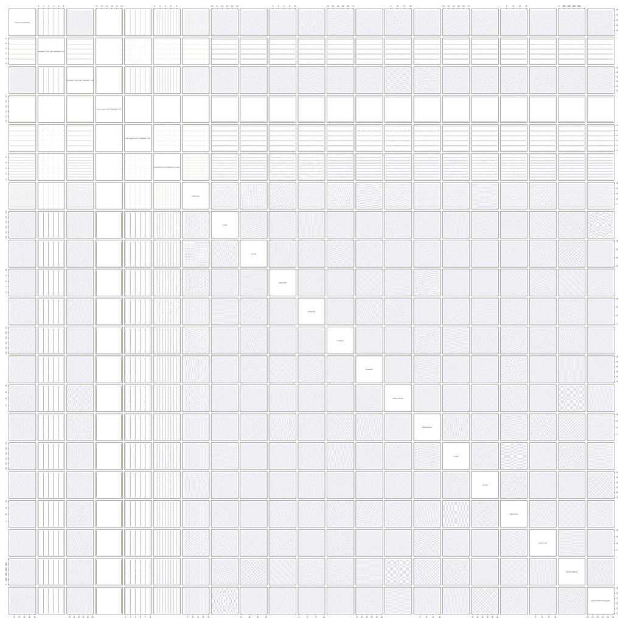

```r
knitr::include_graphics(plotName)
```

Saving parameter configurations (experiments) in separate files:

```r
save_experiment <- function(experiment_df, experiment_row, version_name) {
  write(paste(unlist(experiment_df[experiment_row,], use.names = FALSE)),
        file = paste0(dirname(getwd()), "/analysis/experiments/", version_name, "/", experiment_row, ".txt"))
}

for (i in 1:nrow(params_sobol)) {
  save_experiment(params_sobol, i, "v1.2")
}
```

## Analysis on population end states

> Run experiments in NetLogo Behaviour Space using the parameters `type-of-experiment` and `exp-number`.

### Data loading and preprocessing

Define usable reference to parameter names:

```r
param_names_netlogo <- names(sobol_parameter_ranges)
param_names_r <- gsub("-", ".", names(sobol_parameter_ranges))
```

Loading simulation experiments’ end states:

```r
endstates_matri_v12 <- read.csv("simdata/v1.2/household-demography-main_density exp-endstates-matri-table.csv", skip = 6)
endstates_patri_v12 <- read.csv("simdata/v1.2/household-demography-main_density exp-endstates-patri-table.csv", skip = 6)
```

Preprocess dataset adapting from NetLogo’S specific format. Categorise end states according to whether populations get extinct, survive and/or grow within the maximum number of simulation steps (`max-iterations`).

```r
extract_values_from_NetLogo_list <- function(char_vector) {
  # Remove brackets and split each string into two parts
  split_values <- gsub("\\[|\\]", "", char_vector) |>
    strsplit(" ")

  # Convert to numeric vectors
  first_values <- sapply(split_values, function(x) as.numeric(x[1]))
  second_values <- sapply(split_values, function(x) as.numeric(x[2]))

  # Return as a named list
  list(
    first = first_values,
    second = second_values
  )
}

set_survival_category <- function(population_count, carrying_capacity) {
  survival_category <- ""
  if (population_count > 0) {
    survival_category <- "survival"
    if (population_count > carrying_capacity) {
      survival_category <- paste0(survival_category, " with overshot")
    }
  } else {
    survival_category <- "extinction"
  }
  survival_category
}

preprocess_endstates <- function(endstate_df) {
  household_initial_age_distribution_range <- extract_values_from_NetLogo_list(endstate_df$household.initial.age.distribution)
  max_couple_count_distribution_range <- extract_values_from_NetLogo_list(endstate_df$max.couple.count.distribution)

  endstates <- cbind(
    endstate_df,
    household_initial_age_distribution_min = household_initial_age_distribution_range[[1]],
    household_initial_age_distribution_max = household_initial_age_distribution_range[[2]],
    max_couple_count_distribution_min = max_couple_count_distribution_range[[1]],
    max_couple_count_distribution_max = max_couple_count_distribution_range[[2]]
  )

  endstates |>
    rowwise() |>
    mutate(survival = set_survival_category(totalIndividuals, carrying.capacity)) |>
    ungroup()
}

endstates_matri_v12 <- preprocess_endstates(endstates_matri_v12)
endstates_patri_v12 <- preprocess_endstates(endstates_patri_v12)
```

### Overview of simulation results (population size)

Visualise `totalIndividuals`:

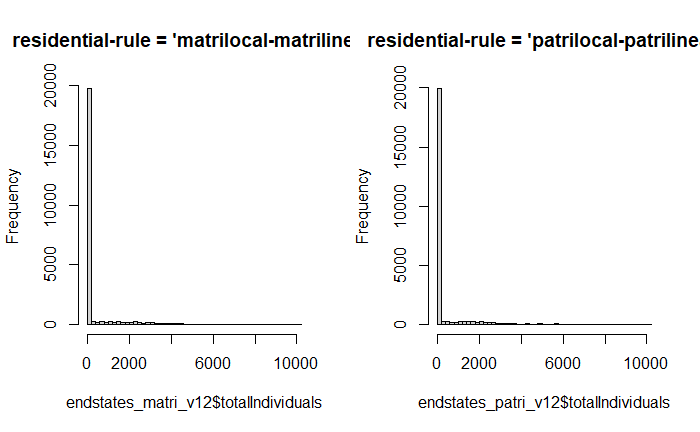

```r
layout(matrix(1:2, ncol = 2))
hist(endstates_matri_v12$totalIndividuals, breaks = 50, main = "residential-rule = 'matrilocal-matrilineal'")
hist(endstates_patri_v12$totalIndividuals, breaks = 50, main = "residential-rule = 'patrilocal-patrilineal'")
```

```r
table(endstates_matri_v12$survival)
```

```
            extinction               survival survival with overshot
                 19552                   4360                     88
```

```r
table(endstates_patri_v12$survival)
```

```
            extinction               survival survival with overshot
                 19681                   4230                     89
```

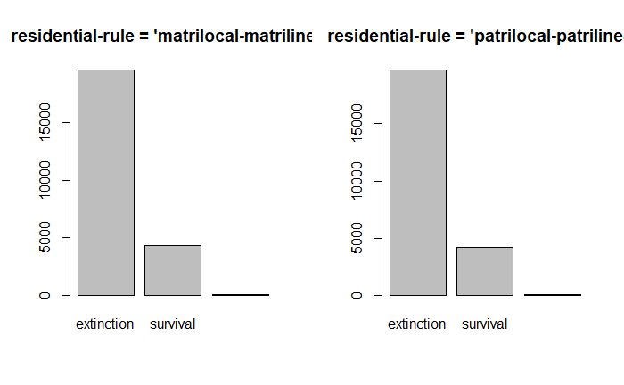

```r
layout(matrix(1:2, ncol = 2))
barplot(table(endstates_matri_v12$survival), main = "residential-rule = 'matrilocal-matrilineal'")
barplot(table(endstates_patri_v12$survival), main = "residential-rule = 'patrilocal-patrilineal'")
```

Visualise `totalIndividuals` in surviving configurations:

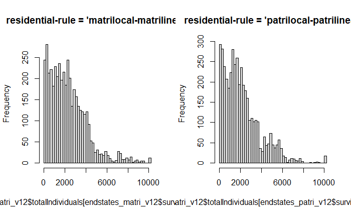

```r
layout(matrix(1:2, ncol = 2))
hist(endstates_matri_v12$totalIndividuals[endstates_matri_v12$survival != "extinction"], breaks = 50, main = "residential-rule = 'matrilocal-matrilineal'")
hist(endstates_patri_v12$totalIndividuals[endstates_patri_v12$survival != "extinction"], breaks = 50, main = "residential-rule = 'patrilocal-patrilineal'")
```

### Visualising population age structure

```r
extract_age_structure <- function(char_value) {
  split_values <- gsub("\\[|\\]", "", char_value) |>
    strsplit(" ")
  as.numeric(split_values[[1]])
}

build_age_structure_df <- function(endstate_df, selected_case = 500, max_age = 110) {
  survival_cases <- endstate_df %>% filter(survival != "extinction")

  age_structure_men <- extract_age_structure(survival_cases[selected_case, "menAgeStructure"])
  age_structure_women <- extract_age_structure(survival_cases[selected_case, "womenAgeStructure"])

  # Put data into long format
  age_structure_df <- tibble(
    age = c(age_structure_men, age_structure_women),
    sex = c(rep("Male", length(age_structure_men)),
            rep("Female", length(age_structure_women)))
  )

  # Bin ages into groups (5-year bins, adjust as needed)
  age_structure_df %>%
    mutate(age_group = cut(age, breaks = seq(0, max_age, 5), right = FALSE))
}

summarise_age_structure_df <- function(age_structure_df) {
  age_structure_df %>%
    count(sex, age_group) %>% # Summarize counts per age group and sex
    mutate(count = ifelse(sex == "Male", -n, n)) # For pyramid: make men negative
}
```

```r
age_structure_matri_v12 <- build_age_structure_df(endstates_matri_v12)
age_structure_patri_v12 <- build_age_structure_df(endstates_patri_v12)
```

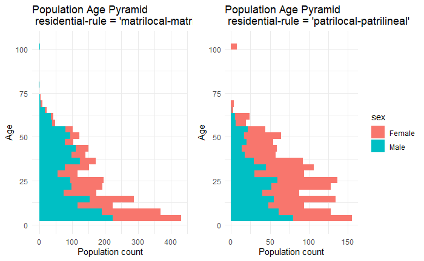

```r
max_age = max(age_structure_matri_v12$age, age_structure_patri_v12$age)
plot_1 <- ggplot(age_structure_matri_v12, aes(x = age, fill = sex)) +
  geom_histogram() +
  coord_flip() +
  scale_y_continuous(labels = abs) +
  lims(x = c(0, max_age + 5)) +
  guides(fill=FALSE) +
  labs(
    title = "Population Age Pyramid \n residential-rule = 'matrilocal-matrilineal'",
    x = "Age",
    y = "Population count"
  ) +
  theme_minimal()

plot_2 <- ggplot(age_structure_patri_v12, aes(x = age, fill = sex)) +
  geom_histogram() +
  coord_flip() +
  scale_y_continuous(labels = abs) +
  lims(x = c(0, max_age + 5)) +
  labs(
    title = "Population Age Pyramid \n residential-rule = 'patrilocal-patrilineal'",
    x = "Age",
    y = "Population count"
  ) +
  theme_minimal()
#
# layout(matrix(1:4, nrow = 2, byrow = TRUE))
# hist(age_structure_matri[sex == "women",], breaks = 101, main = "")
# hist(age_structure_matri_men, breaks = 101, main = "")
# hist(age_structure_patri_women, breaks = 101, main = "")
# hist(age_structure_patri_men, breaks = 101, main = "")
grid.arrange(grobs = c(plot_1, plot_2), ncol = 2, widths = c(1, 1.2))
```

```r
age_structure_matri_summary_v12 <- summarise_age_structure_df(age_structure_matri_v12)
age_structure_patri_summary_v12 <- summarise_age_structure_df(age_structure_patri_v12)
```

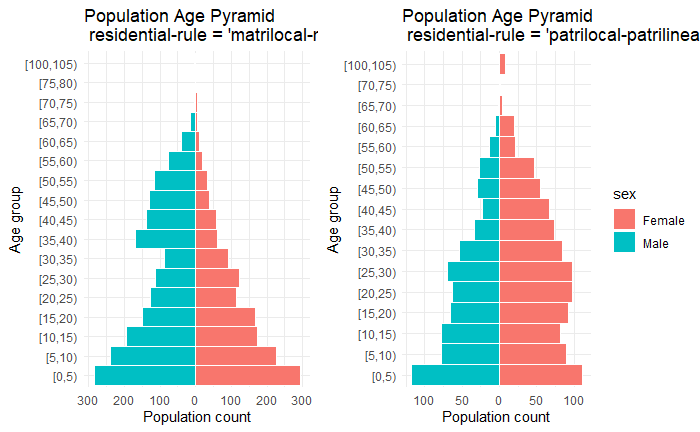

```r
plot_1 <- ggplot(age_structure_matri_summary_v12, aes(x = age_group, y = count, fill = sex)) +
  geom_col(width = 1, color = "white") +
  coord_flip() +
  scale_y_continuous(labels = abs) +
  guides(fill=FALSE) +
  labs(
    title = "Population Age Pyramid \n residential-rule = 'matrilocal-matrilineal'",
    x = "Age group",
    y = "Population count"
  ) +
  theme_minimal()

plot_2 <- ggplot(age_structure_patri_summary_v12, aes(x = age_group, y = count, fill = sex)) +
  geom_col(width = 1, color = "white") +
  coord_flip() +
  scale_y_continuous(labels = abs) +
  labs(
    title = "Population Age Pyramid \n residential-rule = 'patrilocal-patrilineal'",
    x = "Age group",
    y = "Population count"
  ) +
  theme_minimal()

grid.arrange(grobs = c(plot_1, plot_2), ncol = 2, widths = c(1, 1.2))
```

### Identifying survival parameter space

Calculate the Peristera-Kostaki parameter ranges associated to survival:

```r
compute_param_envelope <- function(param_df, low=0.025, high=0.975){
  apply(param_df, 2, quantile, probs = c(low, high), na.rm=TRUE) %>%
    t() %>% as.data.frame() #%>% rename(lower = `2.5%`, upper = `97.5%`)
}

compute_survival_param_space <- function(endstate_df, param_names) {
  compute_param_envelope(endstate_df %>% filter(survival != "extinction") %>% select(all_of(param_names)))
}

param_names_pk <- param_names_r[7:19]

survival_param_space_matri <- compute_survival_param_space(endstates_matri_v12, param_names_pk)
survival_param_space_patri <- compute_survival_param_space(endstates_patri_v12, param_names_pk)
```

With residential-rule = ‘matrilocal-matrilineal’:

```r
knitr::kable(survival_param_space_matri)
```

|  | 2.5% | 97.5% |
| --- | --- | --- |
| cdmlt.level | 9.0000000 | 25.0000000 |
| c1.fert | 0.1813965 | 0.4934082 |
| mu.fert | 15.4907227 | 29.6337891 |
| sigma1.fert | 1.3758423 | 9.8330078 |
| sigma2.fert | 6.0839844 | 19.6777344 |
| c1.women | 0.1396484 | 0.9746094 |
| mu.women | 15.3295898 | 38.1811523 |
| sigma1.women | 2.1503906 | 19.7031250 |
| sigma2.women | 1.7514648 | 19.5421631 |
| c1.men | 0.0493164 | 0.9795532 |
| mu.men | 15.5737305 | 39.3652344 |
| sigma1.men | 1.5102539 | 19.5917969 |
| sigma2.men | 1.5380859 | 19.4619141 |

With residential-rule = ‘patrilocal-patrilineal’:

```r
knitr::kable(survival_param_space_patri)
```

|  | 2.5% | 97.5% |
| --- | --- | --- |
| cdmlt.level | 10.0000000 | 25.0000000 |
| c1.fert | 0.1811523 | 0.4939331 |
| mu.fert | 15.4907227 | 29.5682373 |
| sigma1.fert | 1.2856445 | 9.8259766 |
| sigma2.fert | 6.5014648 | 19.6411133 |
| c1.women | 0.0478516 | 0.9785156 |
| mu.women | 15.4638672 | 38.9257812 |
| sigma1.women | 1.4916992 | 19.5639648 |
| sigma2.women | 1.4453125 | 19.5268555 |
| c1.men | 0.1000977 | 0.9829102 |
| mu.men | 15.3540039 | 39.2187500 |
| sigma1.men | 1.7389404 | 19.7031250 |
| sigma2.men | 1.5937500 | 19.4939209 |

Identify the ranges for the version-specific parameters:

```r
param_names_density <- param_names_r[20:21]

survival_param_space_matri_v12 <- compute_survival_param_space(endstates_matri_v12, param_names_density)
survival_param_space_patri_v12 <- compute_survival_param_space(endstates_patri_v12, param_names_density)
```

With residential-rule = ‘matrilocal-matrilineal’:

```r
knitr::kable(survival_param_space_matri_v12)
```

|  | 2.5% | 97.5% |
| --- | --- | --- |
| carrying.capacity | 341.6992188 | 9700.2929688 |
| density.effect.scaling.factor | 0.0250732 | 0.4887549 |

With residential-rule = ‘patrilocal-patrilineal’:

```r
knitr::kable(survival_param_space_patri_v12)
```

|  | 2.5% | 97.5% |
| --- | --- | --- |
| carrying.capacity | 341.6992188 | 9738.9648438 |
| density.effect.scaling.factor | 0.0195703 | 0.4882764 |

### Identifying relevant factors of survival

```r
param_names_v12 <- c("initial.num.households",
                 "household_initial_age_distribution_min",
                 "household_initial_age_distribution_max",
                 "max_couple_count_distribution_min",
                 "max_couple_count_distribution_max",
                 "acceptable.kinship.degree.for.couples",
                 param_names_pk,
                 param_names_density)

covert_to_long_by_param <- function(df, param_names) {
  df %>%
    pivot_longer(cols = all_of(param_names)) %>%
    mutate(name = factor(name, levels = param_names))  # Preserve order
}
endstates_matri_v12_long <- covert_to_long_by_param(endstates_matri_v12, param_names_v12)
endstates_patri_v12_long <- covert_to_long_by_param(endstates_patri_v12, param_names_v12)
```

```r
source("library/bifurcationPlot.R")

create_bifurcation_plot_multiple <- function(df_long, plot_name, plot_scale = 10, num_columns = 3, width = 80, height = 150, strip_text_size = 1.2) {
  png(plot_name,
      width = width * plot_scale, height = height * plot_scale)

  ggplot(data = df_long, aes(x = value, y = totalIndividuals)) +
    geom_point(alpha = 0.5) +
    geom_smooth(method = "glm") +
    facet_wrap(vars(name), ncol = num_columns, scales = "free_x", as.table = TRUE) +
    theme(
      strip.text = element_text(size = strip_text_size * plot_scale)
    )
  #dev.off()
}

plotName_matri = paste0(plotDirectory, "endstates_matri_bifurcationPlot.png")
create_bifurcation_plot_multiple(endstates_matri_v12_long, plot_name = plotName_matri)

plotName_patri = paste0(plotDirectory, "endstates_patri_bifurcationPlot.png")
create_bifurcation_plot_multiple(endstates_patri_v12_long, plot_name = plotName_patri)
```

```r
knitr::include_graphics(plotName_matri)
```

[figure not shown]

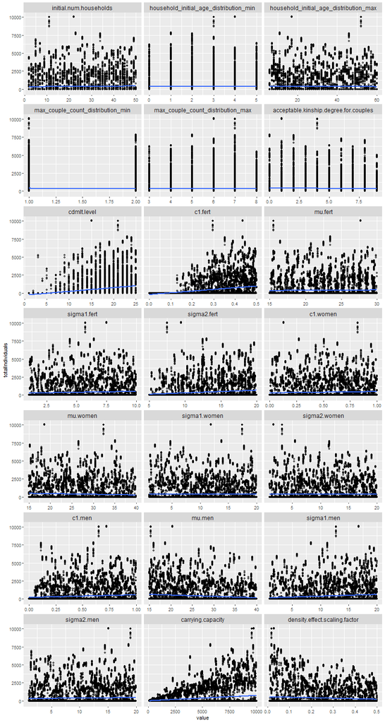

```r
knitr::include_graphics(plotName_patri)
```

Train a Random Forest model to assess parameter importance for each dataset:

```r
run_rf_for_totalIndividuals <- function(endstates_df, param_names, seed = 123) {
  endstates_df <- endstates_df %>% select(all_of(c(param_names, "totalIndividuals")))

  # Train Random Forest to predict simulation output
  set.seed(seed)
  randomForest(totalIndividuals ~ ., data = endstates_df, importance = TRUE, ntree = 500)
}
```

```r
rf_matri <- run_rf_for_totalIndividuals(endstates_matri_v12, param_names_v12)
print(rf_matri)
```

```
Call:
 randomForest(formula = totalIndividuals ~ ., data = endstates_df,      importance = TRUE, ntree = 500)
               Type of random forest: regression
                     Number of trees: 500
No. of variables tried at each split: 7

          Mean of squared residuals: 49206.11
                    % Var explained: 96.42
```

```r
rf_patri <- run_rf_for_totalIndividuals(endstates_patri_v12, param_names_v12)
print(rf_patri)
```

```
Call:
 randomForest(formula = totalIndividuals ~ ., data = endstates_df,      importance = TRUE, ntree = 500)
               Type of random forest: regression
                     Number of trees: 500
No. of variables tried at each split: 7

          Mean of squared residuals: 58785.6
                    % Var explained: 95.06
```

Extract importance values and print as table:

```r
extract_rf_param_importance <- function(rf_model) {
  # Extract importance values
  importance_values <- importance(rf_model)

  # Convert to a data frame
  data.frame(Parameter = rownames(importance_values),
             MDA = importance_values[, 1],
             MDG = importance_values[, 2])
}
```

```r
rf_matri_importance <- extract_rf_param_importance(rf_matri)
print(rf_matri_importance)
```

|  | Parameter | MDA | MDG |
| --- | --- | --- | --- |
| initial.num.households | initial.num.households | 29.17195 | 481977822 |
| household_initial_age_distribution_min | household_initial_age_distribution_min | 25.13991 | 236979205 |
| household_initial_age_distribution_max | household_initial_age_distribution_max | 29.63193 | 575499871 |
| max_couple_count_distribution_min | max_couple_count_distribution_min | 14.01405 | 95616718 |
| max_couple_count_distribution_max | max_couple_count_distribution_max | 26.90945 | 314798007 |
| acceptable.kinship.degree.for.couples | acceptable.kinship.degree.for.couples | 30.49446 | 323701346 |
| cdmlt.level | cdmlt.level | 152.96398 | 5487387585 |
| c1.fert | c1.fert | 142.02703 | 6050073235 |
| mu.fert | mu.fert | 34.70933 | 652597500 |
| sigma1.fert | sigma1.fert | 38.79837 | 1039729611 |

[output cut: 11 more lines]

```r
rf_patri_importance <- extract_rf_param_importance(rf_patri)
print(rf_patri_importance)
```

|  | Parameter | MDA | MDG |
| --- | --- | --- | --- |
| initial.num.households | initial.num.households | 29.81195 | 404561296 |
| household_initial_age_distribution_min | household_initial_age_distribution_min | 26.14356 | 214737470 |
| household_initial_age_distribution_max | household_initial_age_distribution_max | 29.24992 | 559642830 |
| max_couple_count_distribution_min | max_couple_count_distribution_min | 16.98918 | 68204187 |
| max_couple_count_distribution_max | max_couple_count_distribution_max | 20.14446 | 259966858 |
| acceptable.kinship.degree.for.couples | acceptable.kinship.degree.for.couples | 21.44006 | 425658161 |
| cdmlt.level | cdmlt.level | 146.85851 | 4982163294 |
| c1.fert | c1.fert | 149.37883 | 5134169849 |
| mu.fert | mu.fert | 29.96948 | 559875031 |
| sigma1.fert | sigma1.fert | 27.36487 | 627638350 |

[output cut: 11 more lines]

Plot feature importance colouring parameters by domain (general, mortality, fertility, nuptiality, density-related):

```r
source("library/variableImportancePlot.R")

plotName = paste0(plotDirectory, "variableImportancePlot.png")

color_variable_map <- rev(c(
  rep("#0000a2", 5),
  "#bc272d",
  rep("#db9b35", 4),
  rep("#50ad9f", 8),
  rep("#7953b8", 2)
))

# png
png(filename = plotName, width = 2 * 129, height = 168, units="mm", res=1200)

variableImportancePlotPair(rf_matri, rf_patri,
                           title_extra = c("residential-rule = 'matrilocal-matrilineal'", "residential-rule = 'patrilocal-patrilineal'"),
                           plot_scale = 0.5,
                           color_variable_map = color_variable_map,
                           range_standardised = TRUE,
                           log_scale = FALSE,
                           layout_type = 'horizontal')

# layout(matrix(1:2, ncol = 2))
#
# op <- par(no.readonly = TRUE)
#
# par(mar = c(5, 4, 4, 2) + 0.1)
# variableImportancePlot(rf_matri, title_extra = "residential-rule = 'matrilocal-matrilineal'", plot_scale = 0.5, color_variable_map = color_variable_map, range_standardised = TRUE)
#
# par(mar = c(5, 4, 4, 2) + 0.1)
# variableImportancePlot(rf_patri, title_extra = "residential-rule = 'patrilocal-patrilineal'", plot_scale = 0.5, color_variable_map = color_variable_map, range_standardised = TRUE)

dev.off()
```

```r
knitr::include_graphics(plotName)
```

[figure not shown]

#### Initial household population

This parameter has very small positive effect on population survival:

```r
cat("matri | extinct |")
```

```
matri | extinct |
```

```r
endstates_matri_v12 %>%
  filter(totalIndividuals == 0) %>%
  select(initial.num.households) %>%
  summary()
```

```
 initial.num.households
 Min.   : 2.00
 1st Qu.:14.00
 Median :26.00
 Mean   :25.94
 3rd Qu.:38.00
 Max.   :50.00
```

```r
cat("matri | survive |")
```

```
matri | survive |
```

```r
endstates_matri_v12 %>%
  filter(totalIndividuals > 0) %>%
  select(initial.num.households) %>%
  summary()
```

```
 initial.num.households
 Min.   : 2.00
 1st Qu.:15.00
 Median :26.00
 Mean   :26.23
 3rd Qu.:39.00
 Max.   :50.00
```

```r
cat("patri | extinct |")
```

```
patri | extinct |
```

```r
endstates_patri_v12 %>%
  filter(totalIndividuals == 0) %>%
  select(initial.num.households) %>%
  summary()
```

```
 initial.num.households
 Min.   : 2.00
 1st Qu.:14.00
 Median :26.00
 Mean   :25.86
 3rd Qu.:38.00
 Max.   :50.00
```

```r
cat("patri | survive |")
```

```
patri | survive |
```

```r
endstates_patri_v12 %>%
  filter(totalIndividuals > 0) %>%
  select(initial.num.households) %>%
  summary()
```

```
 initial.num.households
 Min.   : 2.0
 1st Qu.:15.0
 Median :27.0
 Mean   :26.6
 3rd Qu.:39.0
 Max.   :50.0
```

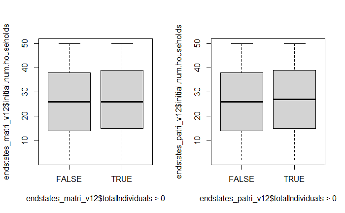

```r
layout(matrix(1:2, ncol = 2))
boxplot(endstates_matri_v12$initial.num.households ~ (endstates_matri_v12$totalIndividuals > 0))
boxplot(endstates_patri_v12$initial.num.households ~ (endstates_patri_v12$totalIndividuals > 0))
```

#### Mortality factors

Coale-Demeny Life Tables Model level parameter has great effect:

```r
cat("matri | extinct |")
```

```
matri | extinct |
```

```r
endstates_matri_v12 %>%
  filter(totalIndividuals == 0) %>%
  select(cdmlt.level) %>%
  summary()
```

```
  cdmlt.level
 Min.   : 1.00
 1st Qu.: 6.00
 Median :11.00
 Mean   :11.65
 3rd Qu.:17.00
 Max.   :25.00
```

```r
cat("matri | survive |")
```

```
matri | survive |
```

```r
endstates_matri_v12 %>%
  filter(totalIndividuals > 0) %>%
  select(cdmlt.level) %>%
  summary()
```

```
  cdmlt.level
 Min.   : 4.00
 1st Qu.:16.00
 Median :20.00
 Mean   :18.89
 3rd Qu.:22.00
 Max.   :25.00
```

```r
cat("patri | extinct |")
```

```
patri | extinct |
```

```r
endstates_patri_v12 %>%
  filter(totalIndividuals == 0) %>%
  select(cdmlt.level) %>%
  summary()
```

```
  cdmlt.level
 Min.   : 1.00
 1st Qu.: 6.00
 Median :11.00
 Mean   :11.61
 3rd Qu.:17.00
 Max.   :25.00
```

```r
cat("patri | survive |")
```

```
patri | survive |
```

```r
endstates_patri_v12 %>%
  filter(totalIndividuals > 0) %>%
  select(cdmlt.level) %>%
  summary()
```

```
  cdmlt.level
 Min.   : 2.0
 1st Qu.:17.0
 Median :20.0
 Mean   :19.3
 3rd Qu.:23.0
 Max.   :25.0
```

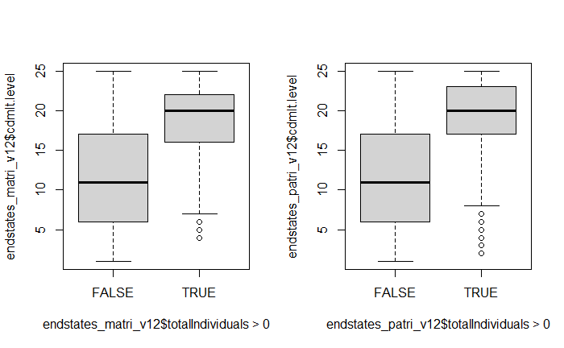

```r
layout(matrix(1:2, ncol = 2))
boxplot(endstates_matri_v12$cdmlt.level ~ (endstates_matri_v12$totalIndividuals > 0))
boxplot(endstates_patri_v12$cdmlt.level ~ (endstates_patri_v12$totalIndividuals > 0))
```

but region parameter has a smaller effect. East tends to survive more often.

```r
cat("matri | survive? |")
```

```
matri | survive? |
```

```r
table(endstates_matri_v12$coale.demeny.region, endstates_matri_v12$totalIndividuals > 0)
```

```
        FALSE TRUE
  east   4765 1235
  north  5017  983
  south  4839 1161
  west   4931 1069
```

```r
cat("patri | survive? |")
```

```
patri | survive? |
```

```r
table(endstates_patri_v12$coale.demeny.region, endstates_patri_v12$totalIndividuals > 0)
```

```
        FALSE TRUE
  east   4808 1192
  north  5048  952
  south  4854 1146
  west   4971 1029
```

#### Fertility factors

```r
layout(matrix(1:4, nrow = 1, byrow = F))
boxplot(endstates_matri_v12$c1.fert ~ (endstates_matri_v12$totalIndividuals > 0), main = "matri - c1.fert")
boxplot(endstates_matri_v12$mu.fert ~ (endstates_matri_v12$totalIndividuals > 0), main = "mu.fert")
```

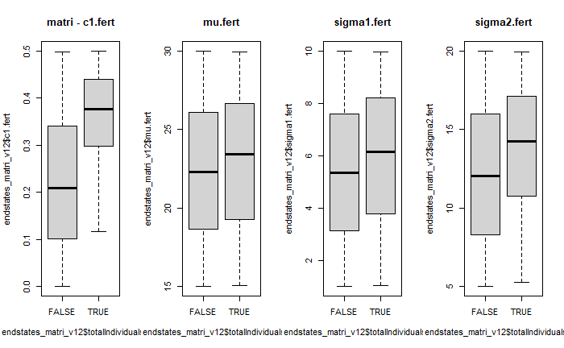

```r
boxplot(endstates_matri_v12$sigma1.fert ~ (endstates_matri_v12$totalIndividuals > 0), main = "sigma1.fert")
boxplot(endstates_matri_v12$sigma2.fert ~ (endstates_matri_v12$totalIndividuals > 0), main = "sigma2.fert")
```

```r
layout(matrix(1:4, nrow = 1, byrow = F))
boxplot(endstates_patri_v12$c1.fert ~ (endstates_patri_v12$totalIndividuals > 0), main = "patri - c1.fert")
boxplot(endstates_patri_v12$mu.fert ~ (endstates_patri_v12$totalIndividuals > 0), main = "mu.fert")
```

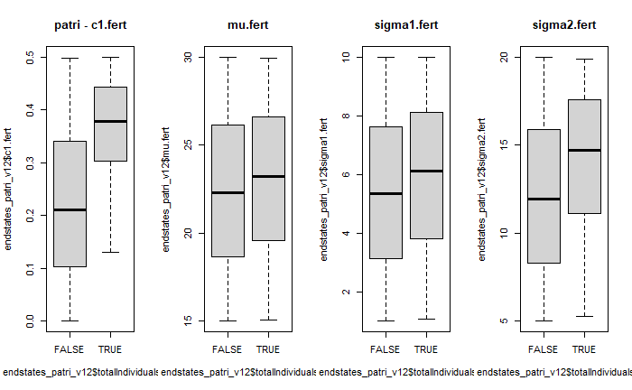

```r
boxplot(endstates_patri_v12$sigma1.fert ~ (endstates_patri_v12$totalIndividuals > 0), main = "sigma1.fert")
boxplot(endstates_patri_v12$sigma2.fert ~ (endstates_patri_v12$totalIndividuals > 0), main = "sigma2.fert")
```

#### Nuptiality factors

Residential rule showing no clear effect:

```r
cat("matri | survive? |")
```

```
matri | survive? |
```

```r
table(endstates_matri_v12$residence.rule, endstates_matri_v12$totalIndividuals > 0)
```

```
                         FALSE  TRUE
  matrilocal-matrilineal 19552  4448
```

```r
cat("patri | survive? |")
```

```
patri | survive? |
```

```r
table(endstates_patri_v12$residence.rule, endstates_patri_v12$totalIndividuals > 0)
```

```
                         FALSE  TRUE
  patrilocal-patrilineal 19681  4319
```

The effect of the acceptable kinship degree is also unclear:

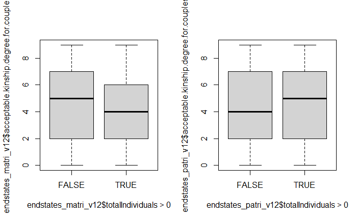

```r
layout(matrix(1:2, ncol = 2))
boxplot(endstates_matri_v12$acceptable.kinship.degree.for.couples ~ (endstates_matri_v12$totalIndividuals > 0))
boxplot(endstates_patri_v12$acceptable.kinship.degree.for.couples ~ (endstates_patri_v12$totalIndividuals > 0))
```

```r
layout(matrix(1:8, nrow = 2, byrow = F))
boxplot(endstates_matri_v12$c1.women ~ (endstates_matri_v12$totalIndividuals > 0), main = "matri- c1.women")
boxplot(endstates_matri_v12$mu.women ~ (endstates_matri_v12$totalIndividuals > 0), main = "mu.women")
```

```r
boxplot(endstates_matri_v12$sigma1.women ~ (endstates_matri_v12$totalIndividuals > 0), main = "sigma1.women")
boxplot(endstates_matri_v12$sigma2.women ~ (endstates_matri_v12$totalIndividuals > 0), main = "sigma2.women")
```

```r
boxplot(endstates_matri_v12$c1.men ~ (endstates_matri_v12$totalIndividuals > 0), main = "c1.men")
boxplot(endstates_matri_v12$mu.men ~ (endstates_matri_v12$totalIndividuals > 0), main = "mu.men")
```

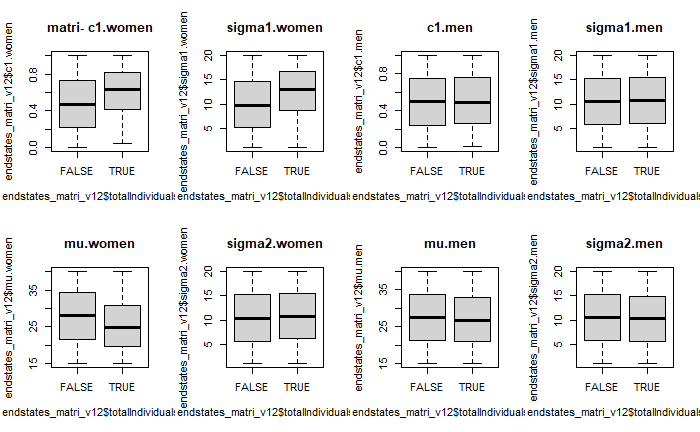

```r
boxplot(endstates_matri_v12$sigma1.men ~ (endstates_matri_v12$totalIndividuals > 0), main = "sigma1.men")
boxplot(endstates_matri_v12$sigma2.men ~ (endstates_matri_v12$totalIndividuals > 0), main = "sigma2.men")
```

```r
layout(matrix(1:8, nrow = 2, byrow = F))
boxplot(endstates_patri_v12$c1.women ~ (endstates_patri_v12$totalIndividuals > 0), main = "patri - c1.women")
boxplot(endstates_patri_v12$mu.women ~ (endstates_patri_v12$totalIndividuals > 0), main = "mu.women")
```

```r
boxplot(endstates_patri_v12$sigma1.women ~ (endstates_patri_v12$totalIndividuals > 0), main = "sigma1.women")
boxplot(endstates_patri_v12$sigma2.women ~ (endstates_patri_v12$totalIndividuals > 0), main = "sigma2.women")
```

```r
boxplot(endstates_patri_v12$c1.men ~ (endstates_patri_v12$totalIndividuals > 0), main = "c1.men")
boxplot(endstates_patri_v12$mu.men ~ (endstates_patri_v12$totalIndividuals > 0), main = "mu.men")
```

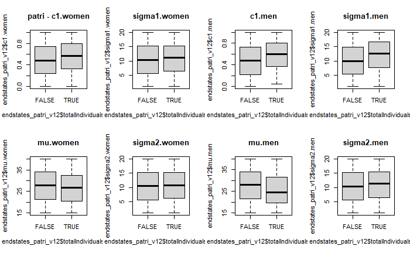

```r
boxplot(endstates_patri_v12$sigma1.men ~ (endstates_patri_v12$totalIndividuals > 0), main = "sigma1.men")
boxplot(endstates_patri_v12$sigma2.men ~ (endstates_patri_v12$totalIndividuals > 0), main = "sigma2.men")
```

#### Density factors

Both parameters have a visible effect. Unsurprisingly, the carrying capacity has the stronger effect.

```r
cat("matri | extinct |")
```

```
matri | extinct |
```

```r
endstates_matri_v12 %>%
  filter(totalIndividuals == 0) %>%
  select(carrying.capacity) %>%
  summary()
```

```
 carrying.capacity
 Min.   : 104.8
 1st Qu.:2502.5
 Median :4999.2
 Mean   :5023.8
 3rd Qu.:7534.7
 Max.   :9995.2
```

```r
cat("matri | survive |")
```

```
matri | survive |
```

```r
endstates_matri_v12 %>%
  filter(totalIndividuals > 0) %>%
  select(carrying.capacity) %>%
  summary()
```

```
 carrying.capacity
 Min.   : 109.7
 1st Qu.:2884.4
 Median :5325.5
 Mean   :5175.5
 3rd Qu.:7505.7
 Max.   :9971.0
```

```r
cat("patri | extinct |")
```

```
patri | extinct |
```

```r
endstates_patri_v12 %>%
  filter(totalIndividuals == 0) %>%
  select(carrying.capacity) %>%
  summary()
```

```
 carrying.capacity
 Min.   : 104.8
 1st Qu.:2546.0
 Median :5025.8
 Mean   :5037.6
 3rd Qu.:7529.8
 Max.   :9995.2
```

```r
cat("patri | survive |")
```

```
patri | survive |
```

```r
endstates_patri_v12 %>%
  filter(totalIndividuals > 0) %>%
  select(carrying.capacity) %>%
  summary()
```

```
 carrying.capacity
 Min.   : 109.7
 1st Qu.:2695.8
 Median :5180.5
 Mean   :5117.2
 3rd Qu.:7505.7
 Max.   :9971.0
```

```r
cat("matri | extinct |")
```

```
matri | extinct |
```

```r
endstates_matri_v12 %>%
  filter(totalIndividuals == 0) %>%
  select(density.effect.scaling.factor) %>%
  summary()
```

```
 density.effect.scaling.factor
 Min.   :0.01024
 1st Qu.:0.13226
 Median :0.25285
 Mean   :0.25394
 3rd Qu.:0.37606
 Max.   :0.49976
```

```r
cat("matri | survive |")
```

```
matri | survive |
```

```r
endstates_matri_v12 %>%
  filter(totalIndividuals > 0) %>%
  select(density.effect.scaling.factor) %>%
  summary()
```

```
 density.effect.scaling.factor
 Min.   :0.01096
 1st Qu.:0.13489
 Median :0.26744
 Mean   :0.26043
 3rd Qu.:0.38540
 Max.   :0.49952
```

```r
cat("patri | extinct |")
```

```
patri | extinct |
```

```r
endstates_patri_v12 %>%
  filter(totalIndividuals == 0) %>%
  select(density.effect.scaling.factor) %>%
  summary()
```

```
 density.effect.scaling.factor
 Min.   :0.01024
 1st Qu.:0.13250
 Median :0.25500
 Mean   :0.25455
 3rd Qu.:0.37606
 Max.   :0.49976
```

```r
cat("patri | survive |")
```

```
patri | survive |
```

```r
endstates_patri_v12 %>%
  filter(totalIndividuals > 0) %>%
  select(density.effect.scaling.factor) %>%
  summary()
```

```
 density.effect.scaling.factor
 Min.   :0.01096
 1st Qu.:0.13633
 Median :0.25787
 Mean   :0.25782
 3rd Qu.:0.38348
 Max.   :0.49952
```

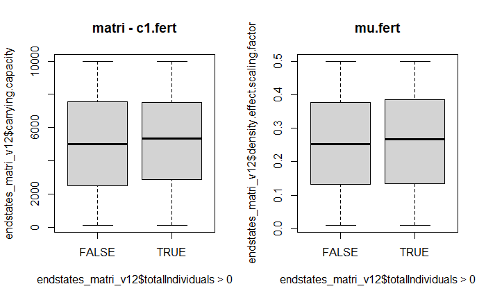

```r
layout(matrix(1:2, nrow = 1, byrow = F))
boxplot(endstates_matri_v12$carrying.capacity ~ (endstates_matri_v12$totalIndividuals > 0), main = "matri - c1.fert")
boxplot(endstates_matri_v12$density.effect.scaling.factor ~ (endstates_matri_v12$totalIndividuals > 0), main = "mu.fert")
```

## Stochasticity and trajectory variation

> Run experiments in NetLogo Behaviour Space using parameter configurations where populations tend to survive, according to the exploration above.

Loading simulation experiments’ end states:

```r
trajectories_v11 <- read.csv("simdata/v1.1/household-demography-main exp-trajectories-table.csv", skip = 6)
trajectories_v12 <- read.csv("simdata/v1.2/household-demography-main_density exp-trajectories-table.csv", skip = 6)
```

Preprocess dataset adapting from NetLogo’S specific format. Categorise end states according to whether populations get extinct, survive and/or grow beyond the carrying capacity (“overshooting”).

```r
extract_values_from_NetLogo_list <- function(char_vector) {
  # Remove brackets and split each string into two parts
  split_values <- gsub("\\[|\\]", "", char_vector) |>
    strsplit(" ")

  # Convert to numeric vectors
  first_values <- sapply(split_values, function(x) as.numeric(x[1]))
  second_values <- sapply(split_values, function(x) as.numeric(x[2]))

  # Return as a named list
  list(
    first = first_values,
    second = second_values
  )
}

preprocess_params <- function(trajectories_df) {
  household_initial_age_distribution_range <- extract_values_from_NetLogo_list(trajectories_df$household.initial.age.distribution)
  max_couple_count_distribution_range <- extract_values_from_NetLogo_list(trajectories_df$max.couple.count.distribution)

  cbind(
    trajectories_df,
    household_initial_age_distribution_min = household_initial_age_distribution_range[[1]],
    household_initial_age_distribution_max = household_initial_age_distribution_range[[2]],
    max_couple_count_distribution_min = max_couple_count_distribution_range[[1]],
    max_couple_count_distribution_max = max_couple_count_distribution_range[[2]]
  )
}
```

```r
MAX_POPULATION = trajectories_v11$max.population[1]

set_survival_category_v11 <- function(trajectories_df) {
  trajectories_df |>
    group_by(X.run.number.) |>
    mutate(
      endstate_total_individuals = dplyr::last(totalIndividuals),
      survival = case_when(
        endstate_total_individuals <= 0 ~ "extinction",
        endstate_total_individuals > MAX_POPULATION ~ "survival with growth",
        TRUE ~ "survival"
      )
    ) |>
    ungroup()
}

trajectories_v11 <- trajectories_v11 |>
  preprocess_params() |>
  set_survival_category_v11()
```

```r
CARRYING_CAPACITY = trajectories_v12$par_carrying.capacity[1]

set_survival_category_v12 <- function(trajectories_df) {
  trajectories_df |>
    group_by(X.run.number.) |>
    mutate(
      endstate_total_individuals = dplyr::last(totalIndividuals),
      survival = case_when(
        endstate_total_individuals <= 0 ~ "extinction",
        endstate_total_individuals > par_carrying.capacity ~ "survival with growth",
        TRUE ~ "survival"
      )
    ) |>
    ungroup()
}

trajectories_v12 <- trajectories_v12 |>
  preprocess_params() |>
  set_survival_category_v12()
```

Process parameters in list format in NetLogo:

```r
param_names_v11 <- c("initial.num.households",
                     "household_initial_age_distribution_min",
                     "household_initial_age_distribution_max",
                     "max_couple_count_distribution_min",
                     "max_couple_count_distribution_max",
                     "acceptable.kinship.degree.for.couples",
                     param_names_pk)
```

```r
plot_name <- file.path(paste0(plotDirectory, "HouseholdDemography-trajectories_v11-v12.", plot_file_format))

if (plot_file_format == "png") {
  graphic_scale <- 1
  legend_text_rescale <- legend_key_rescale <- graphic_scale * -0.5
  axis_text_rescale <- axis_title_rescale <- graphic_scale * -0.5

  png(plot_name, width = graphic_scale * 1600, height = graphic_scale * 800, res = 300, pointsize = 4)
} else if (plot_file_format == "eps") {
  graphic_scale = 1.2
  # font_rescale = -0.2
  # axis_text_rescale = -0.1
  # margin_text_rescale = -0.5

  extrafont::loadfonts(device = "postscript")
  grDevices::cairo_ps(filename = plot_name ,
                      pointsize = 12,
                      width = graphic_scale * 8,
                      height = graphic_scale * 4,
                      onefile = FALSE,
                      family = "sans"
                      )
}

p1 <- ggplot(trajectories_v11, aes(x = X.step., y = totalIndividuals, group = X.run.number., color = residence.rule)) +
  geom_line(linewidth = .1) +
  ggtitle("v.1.1") +
  xlab("time (years)") +
  ylab("population (individuals)") +
  guides(color = "none") +
  theme_minimal() +
  theme(axis.title = element_text(size = 10 * (graphic_scale + axis_title_rescale)),
        axis.text = element_text(size = 10 * (graphic_scale + axis_text_rescale)))

p2 <- ggplot(trajectories_v12, aes(x = X.step., y = totalIndividuals, group = X.run.number., color = residence.rule)) +
  geom_line(linewidth = .1) +
  geom_hline(yintercept = as.numeric(CARRYING_CAPACITY)) +
  ggtitle("v.1.2") +
  xlab("time (years)") +
  ylab("") +
  guides(color = guide_legend(title="Residential\nrule", override.aes = list(linewidth = 2), reverse = TRUE)) +
  theme_minimal() +
  theme(axis.title = element_text(size = 10 * (graphic_scale + axis_title_rescale)),
        axis.text = element_text(size = 10 * (graphic_scale + axis_text_rescale)),
        legend.title = element_text(size = 10 * (graphic_scale + legend_text_rescale)),
        legend.text = element_text(size = 10 * (graphic_scale + legend_text_rescale)),
        legend.key.width = unit(2 * (graphic_scale + legend_key_rescale), 'lines'),
        legend.key.height = unit(2 * (graphic_scale + legend_key_rescale), 'lines'))

p3 <- grid.arrange(p1, p2, ncol = 2, widths = c(1, 1.4))

dev.off()
```

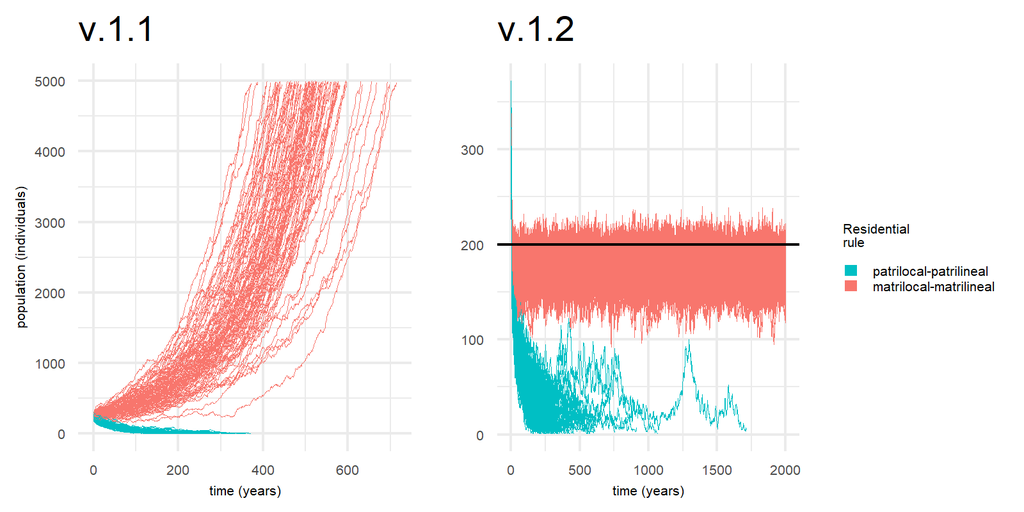

```r
knitr::include_graphics(plot_name)
```

## Analysis on population end states in v1.2.1

> Run experiments in NetLogo Behaviour Space using the parameters `type-of-experiment` and `exp-number`.

Note that v1.2.1 does not require additional parameters, so the same set of experiment configurations can be used.

```r
plotDirectory <- "plots/v121_"
plot_file_format <- c("png", "eps")[1] # modify index number to change format
```

### Data loading and preprocessing

Loading simulation experiments’ end states:

```r
endstates_matri_v121 <- read.csv("simdata/v1.2.1/household-demography-main_density-K-demand exp-endstates-matri-table.csv", skip = 6)
endstates_patri_v121 <- read.csv("simdata/v1.2.1/household-demography-main_density-K-demand exp-endstates-patri-table.csv", skip = 6)
```

Preprocess dataset adapting from NetLogo’S specific format. Categorise end states according to whether populations get extinct, survive and/or grow within the maximum number of simulation steps (`max-iterations`).

```r
MAX_POPULATION = endstates_matri_v121$max.population[1]

endstates_matri_v121 <- preprocess_endstates(endstates_matri_v121)
endstates_patri_v121 <- preprocess_endstates(endstates_patri_v121)
```

### Overview of simulation results (population size)

Visualise `totalIndividuals`:

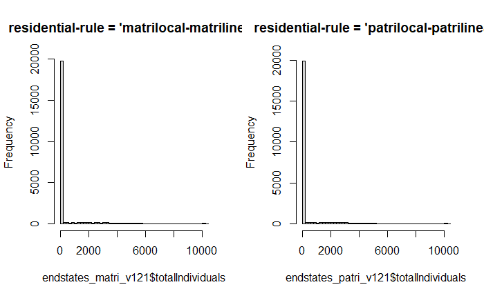

```r
layout(matrix(1:2, ncol = 2))
hist(endstates_matri_v121$totalIndividuals, breaks = 50, main = "residential-rule = 'matrilocal-matrilineal'")
hist(endstates_patri_v121$totalIndividuals, breaks = 50, main = "residential-rule = 'patrilocal-patrilineal'")
```

```r
table(endstates_matri_v121$survival)
```

```
            extinction               survival survival with overshot
                 19540                   4063                    397
```

```r
table(endstates_patri_v121$survival)
```

```
            extinction               survival survival with overshot
                 19680                   3985                    335
```

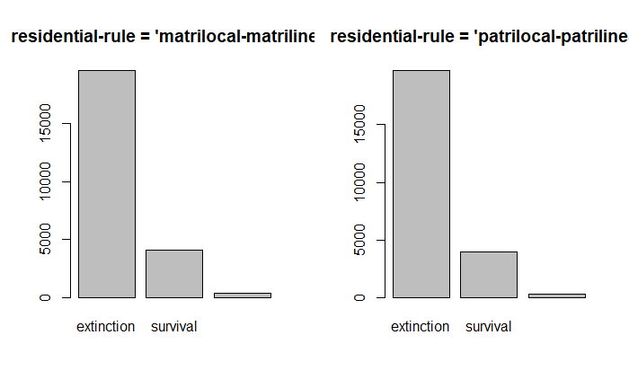

```r
layout(matrix(1:2, ncol = 2))
barplot(table(endstates_matri_v121$survival), main = "residential-rule = 'matrilocal-matrilineal'")
barplot(table(endstates_patri_v121$survival), main = "residential-rule = 'patrilocal-patrilineal'")
```

Visualise `totalIndividuals` in surviving configurations:

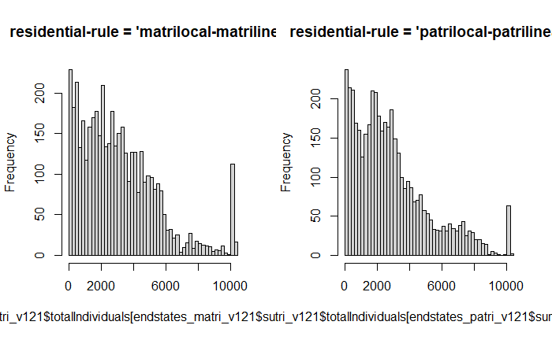

```r
layout(matrix(1:2, ncol = 2))
hist(endstates_matri_v121$totalIndividuals[endstates_matri_v121$survival != "extinction"], breaks = 50, main = "residential-rule = 'matrilocal-matrilineal'")
hist(endstates_patri_v121$totalIndividuals[endstates_patri_v121$survival != "extinction"], breaks = 50, main = "residential-rule = 'patrilocal-patrilineal'")
```

### Visualising population age structure

```r
age_structure_matri_v121 <- build_age_structure_df(endstates_matri_v121)
age_structure_patri_v121 <- build_age_structure_df(endstates_patri_v121)
```

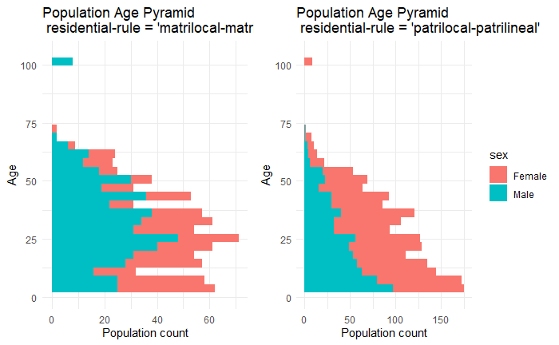

```r
max_age = max(age_structure_matri_v121$age, age_structure_patri_v121$age)
plot_1 <- ggplot(age_structure_matri_v121, aes(x = age, fill = sex)) +
  geom_histogram() +
  coord_flip() +
  scale_y_continuous(labels = abs) +
  lims(x = c(0, max_age + 5)) +
  guides(fill=FALSE) +
  labs(
    title = "Population Age Pyramid \n residential-rule = 'matrilocal-matrilineal'",
    x = "Age",
    y = "Population count"
  ) +
  theme_minimal()

plot_2 <- ggplot(age_structure_patri_v121, aes(x = age, fill = sex)) +
  geom_histogram() +
  coord_flip() +
  scale_y_continuous(labels = abs) +
  lims(x = c(0, max_age + 5)) +
  labs(
    title = "Population Age Pyramid \n residential-rule = 'patrilocal-patrilineal'",
    x = "Age",
    y = "Population count"
  ) +
  theme_minimal()
#
# layout(matrix(1:4, nrow = 2, byrow = TRUE))
# hist(age_structure_matri[sex == "women",], breaks = 101, main = "")
# hist(age_structure_matri_men, breaks = 101, main = "")
# hist(age_structure_patri_women, breaks = 101, main = "")
# hist(age_structure_patri_men, breaks = 101, main = "")
grid.arrange(grobs = c(plot_1, plot_2), ncol = 2, widths = c(1, 1.2))
```

```r
age_structure_matri_summary_v121 <- summarise_age_structure_df(age_structure_matri_v121)
age_structure_patri_summary_v121 <- summarise_age_structure_df(age_structure_patri_v121)
```

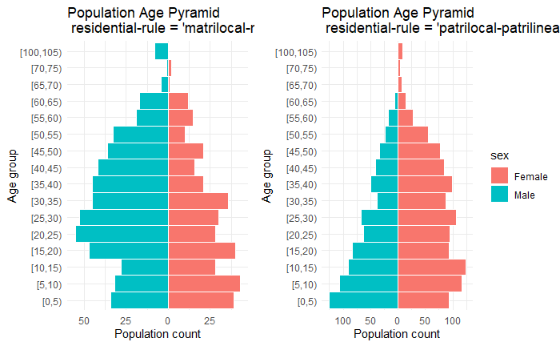

```r
plot_1 <- ggplot(age_structure_matri_summary_v121, aes(x = age_group, y = count, fill = sex)) +
  geom_col(width = 1, color = "white") +
  coord_flip() +
  scale_y_continuous(labels = abs) +
  guides(fill=FALSE) +
  labs(
    title = "Population Age Pyramid \n residential-rule = 'matrilocal-matrilineal'",
    x = "Age group",
    y = "Population count"
  ) +
  theme_minimal()

plot_2 <- ggplot(age_structure_patri_summary_v121, aes(x = age_group, y = count, fill = sex)) +
  geom_col(width = 1, color = "white") +
  coord_flip() +
  scale_y_continuous(labels = abs) +
  labs(
    title = "Population Age Pyramid \n residential-rule = 'patrilocal-patrilineal'",
    x = "Age group",
    y = "Population count"
  ) +
  theme_minimal()

grid.arrange(grobs = c(plot_1, plot_2), ncol = 2, widths = c(1, 1.2))
```

### Identifying relevant factors of survival

```r
covert_to_long_by_param <- function(df, param_names) {
  df %>%
    pivot_longer(cols = all_of(param_names)) %>%
    mutate(name = factor(name, levels = param_names))  # Preserve order
}
endstates_matri_v121_long <- covert_to_long_by_param(endstates_matri_v121, param_names_v12)
endstates_patri_v121_long <- covert_to_long_by_param(endstates_patri_v121, param_names_v12)
```

```r
source("library/bifurcationPlot.R")

create_bifurcation_plot_multiple <- function(df_long, plot_name, plot_scale = 10, num_columns = 3, width = 80, height = 150, strip_text_size = 1.2) {
  png(plot_name,
      width = width * plot_scale, height = height * plot_scale)

  ggplot(data = df_long, aes(x = value, y = totalIndividuals)) +
    geom_point(alpha = 0.5) +
    geom_smooth(method = "glm") +
    facet_wrap(vars(name), ncol = num_columns, scales = "free_x", as.table = TRUE) +
    theme(
      strip.text = element_text(size = strip_text_size * plot_scale)
    )
  #dev.off()
}

plotName_matri = paste0(plotDirectory, "endstates_matri_bifurcationPlot.png")
create_bifurcation_plot_multiple(endstates_matri_v121_long, plot_name = plotName_matri)

plotName_patri = paste0(plotDirectory, "endstates_patri_bifurcationPlot.png")
create_bifurcation_plot_multiple(endstates_patri_v121_long, plot_name = plotName_patri)
```

```r
knitr::include_graphics(plotName_matri)
```

[figure not shown]

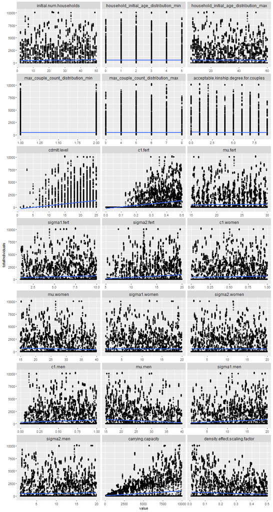

```r
knitr::include_graphics(plotName_patri)
```